# Use of Prescription Medications That Potentially Interfere With Blood Pressure Control in New-Onset Hypertension and Treatment-Resistant Hypertension | American Journal of Hypertension | Oxford Academ

[figure not shown]

[Journals](https://academic.oup.com/journals)

[Books](https://academic.oup.com/books)

[figure not shown]

Article Navigation

[figure not shown]

Volume 31

Issue 12

December 2018

### Article Contents

Journal Article

# Use of Prescription Medications That Potentially Interfere With Blood Pressure Control in New-Onset Hypertension and Treatment-Resistant Hypertension

Andrew Y Hwang, Chintan V Dave, Steven M Smith

*American Journal of Hypertension*, Volume 31, Issue 12, December 2018, Pages 1324–1331, https://doi.org/10.1093/ajh/hpy118

Published:

25 July 2018

Article history

## Abstract

BACKGROUND

Withdrawing medications that interfere with blood pressure (BP) is recommended in patients with uncontrolled BP, yet real-world use of such agents is not well characterized among individuals with hypertension. We aimed to evaluate the use of BP-interfering prescription medications among US patients with hypertension.

METHODS

This retrospective drug utilization study used medical and prescription claims (January 2008 to December 2014) in the MarketScan commercial claims database. We included adults, aged 18–65 years, with a hypertension diagnosis (*International Classification of Diseases, Ninth Revision*, code 401) and ≥1 antihypertensive medication fill. Two hypertension cohorts were examined—new antihypertensive drug users (incident hypertension) and patients requiring titration to a fourth antihypertensive (incident treatment-resistant hypertension [TRH]). Patient-level exposure to BP-interfering medications was assessed 6 months before and after the index date, defined as the first prescription fill of an antihypertensive drug or the first occurrence of overlapping use of ≥4 antihypertensive drugs.

RESULTS

We identified 521,028 patients with incident hypertension and 131,764 patients with incident TRH. The most prevalent BP-interfering prescription medications were nonsteroidal anti-inflammatory drugs (NSAIDs), acetaminophens, and hormones. Overall, 18.3% of the incident hypertension cohort and 17.6% of the incident TRH cohort initiated a BP-interfering medication following antihypertensive titration. Among patients previously taking a BP-interfering medication, 57.6% with incident hypertension and 64.9% with incident TRH refilled that medication after antihypertensive intensification.

CONCLUSIONS

The use of prescription BP-interfering medications, especially NSAIDs, is prevalent among patients requiring intensification of their antihypertensive regimen. Greater efforts to limit the use of these medications, where feasible, may be required among patients with uncontrolled hypertension.

acetaminophen, blood pressure, hypertension, interference, prevalence, nonsteroidal anti-inflammatory drugs, resistant hypertension

Subject

[Epidemiology](https://academic.oup.com/ajh/search-results?page=1&tax=ajhype/ajh-08)

Issue Section:

Pharmacology

Hypertension, the most common chronic disease, affects approximately 103.3 million adults in the United States and 1.4 billion adults worldwide.<sup>1,2</sup> Prior studies have demonstrated the importance of blood pressure (BP) reduction and linked uncontrolled hypertension to an increased cardiovascular risk.<sup>3–6</sup> Although attaining high BP control rates is feasible in the clinical trial setting, achieving similarly high BP control in the real world has been challenging. For example, awareness and treatment of hypertension have increased substantially over the past half century in the United States; yet, these changes have been followed by only modest improvements in BP control nationwide.<sup>7</sup> Moreover, difficult-to-control hypertension phenotypes, such as treatment-resistant hypertension (TRH), continue to rise.<sup>7</sup>

The exact etiologies contributing to uncontrolled BP are incompletely understood but may include suboptimal regimens, nonadherence, and clinical inertia. Drug interactions also may play a significant role and numerous medications have been shown to increase BP and interfere with BP control.<sup>8</sup> Identification and withdrawal of potentially interfering medications is generally recommended as part of the management of uncontrolled hypertension, particularly in patients with more severe and difficult-to-treat phenotypes such as TRH.<sup>9</sup> Yet, little is known regarding the scale of use of these medications in the general population with hypertension, and particularly, in patients with more difficult-to-control phenotypes requiring antihypertensive regimen titration. Therefore, we aimed to characterize the use of medications that can interfere with BP control among patients with hypertension. Because the use of interfering medications is most pertinent, clinically, in patients with uncontrolled BP, we focused our investigation on analyzing the use of these medications in conjunction with incident hypertension and incident TRH—i.e., in patients requiring initial antihypertensive therapy or substantial antihypertensive titration, respectively. The latter group was included to explore the extent to which these drugs may contribute to particularly difficult-to-control hypertension phenotypes and to allow for comparison between early and more advanced stages of hypertension.

## METHODS

### Study design and data sources

We performed a drug utilization study to examine the use of potential BP-interfering medications among 2 hypertension cohorts: (i) patients with incident hypertension, requiring initial pharmacological antihypertensive treatment and (ii) patients with incident TRH, requiring the addition of a fourth antihypertensive agent. We analyzed medical and prescription administrative claims data from January 2008 to December 2014 in the MarketScan commercial claims database, which is representative of Americans receiving employer-based insurance (approximately 55% of the US population).<sup>10</sup> MarketScan covers approximately 30 million patients annually and receives health-care utilization data from 130 employer-sponsored health plans across the United States. The study was designed by the authors and approved by the Institutional Review Board at the University of Florida.

### Cohort development

Figure 1 summarizes cohort identification for those with incident hypertension and incident TRH. In both cohorts, we included adults aged 18–65 years, with evidence of primary hypertension (*International Classification of Diseases, Ninth Revision*, code 401.X) and no evidence of heart failure (*International Classification of Diseases, Ninth Revision*, code 428.X). For the incident hypertension cohort, we identified patients newly initiated on an antihypertensive medication after a 6-month look-back period. To ensure pharmacy utilization, patients were required to have at least 1 non-antihypertensive prescription fill during this look-back period. The index date for the incident hypertension cohort was defined as the first fill date for an antihypertensive medication. A detailed description of the development of the incident TRH cohort has been previously published.<sup>11</sup> Briefly, the incident TRH cohort was derived from all patients with treated hypertension, including patients with incident hypertension during the study period and patients with prevalent treated hypertension at study entry. Patients with incident TRH were required to have at least 60 days of overlapping use of ≥4 antihypertensive drugs, and each antihypertensive drug was required to have been filled at least twice. The index date for the incident TRH cohort was defined as the first occurrence of concurrent use of 4 antihypertensive drugs. For both cohorts, patients were also required to have continuous health-care eligibility 9 months before, and 6 months after, their index date. Comorbid conditions were assessed in the 9-month period before and including the index date.

Figure 1.

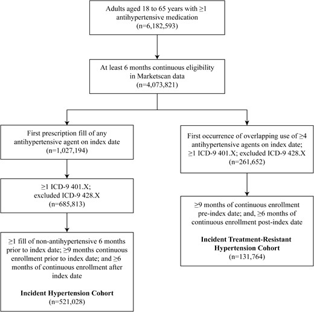

Flow diagram illustrating the development of the 2 hypertensive cohorts. Abbreviation: TRH, treatment-resistant hypertension.

### Identification and selection of interfering medications

We performed a literature review of English-language publications between January 1966 and September 2016 from searches of PubMed using key terms “blood pressure,” “interfering,” “drugs,” “drug-induced,” and “hypertension.” Review articles describing medications or substances that can potentially interfere with BP control and contribute to secondary hypertension were individually searched for additional references.<sup>8,12,13</sup> Interfering medications were then selected based on the availability of published data supporting their effects on increasing BP. Where possible, we combined interfering medications according to therapeutic class (i.e., nonsteroidal anti-inflammatory drugs [NSAIDs]) or putative mechanism of BP elevation. Specifically, drugs were assigned to one of the following categories: acetaminophen, angiogenesis inhibitors, antidepressants, aspirin, buspirone, corticosteroids, erythropoiesis-stimulating agents, hormones, immunosuppressants, NSAIDs, stimulants, and sympathomimetics. NSAIDs were also studied individually. Only systemic formulations (e.g., oral, parenteral) of the drugs were included in our analysis. Specific drugs included within each category are listed in Supplementary Table 1.

### Analysis

We analyzed utilization patterns of prescription BP-interfering medications among patients with incident hypertension and incident TRH, and used these prescription fill data as a surrogate for drug exposure (as commonly used in pharmacoepidemiology studies<sup>14–16</sup>) to determine the proportion of patients in each cohort who were exposed to the specific BP-interfering drug or class of drugs. For hormones only, the denominator was women in each cohort. We calculated the patient-level daily exposure by using the date of fill and reported days’ supply of the BP-interfering drug. The daily exposure of the drug was plotted to assess use of the specific BP-interfering drug or drug class during the 6 months before and 6 months after the index date for each cohort. Because our focus was on any exposure to these drugs, we collapsed all drug strengths/doses and products into a single exposure variable for each drug. Overall use of a given drug or class was operationalized as proportion of patients exposed to the drug or class on the index date.

To assess initiation of interfering drugs after intensifying antihypertensive therapy, we identified the proportion of new users (“initiators”) for each interfering drug or class after the index date in each cohort. This measure was operationalized as the proportion of patients with an initial prescription fill occurring within 6 months after the index date. Additionally, to investigate continued use of interfering drugs following a need for antihypertensive therapy titration, we evaluated users in both cohorts who continued to fill a specific BP-interfering medication after the index date (“continuers”). This measure was operationalized as the proportion of patients with at least 1 prescription refill during the 6 months after the index date, among patients who had filled the same drug or class before the index date.